# Lab Assignment One – Data Exploration and Analysis

##### An introductory lab assignment with the purpose of exploring data set analysis, data visualzation, and making conclusions about analysis findings.

For this lab assignment, I will be using the UCI Machine Learning Repository's Diabetes data set. The data set contains 100,000 instances, each containing attributes related to patients with diabetes specifically in relation to patient readmission over time. The data set is derived from the Center for Clinical and Translational Research, Virginia Commonwealth University. [[Source](https://archive.ics.uci.edu/ml/datasets/Diabetes+130-US+hospitals+for+years+1999-2008#)]

### Business Understanding

The UCI Repository's Diabetes data set contains information about patients diagnosed with Diabetes. The data was most likely collected as part of routine patient documentation, however, the primary purpose its compilation and analysis is to identify correlations that may provide insight into the progression of the disease and how patients may best be treated in order to increase both the quality and length of life, in turn reducing the number of readmissions after the initial diagnosis.  
Outcomes from data set analysis will consist of any statistically significant correlations between attributes. The effectiveness of any prediction or clustering algoritm that takes advantage of these findings would be determined by the the accuracy with which it identifies patient readmission and when readmission will occur (<30 days or >30 days).

### Data Understanding

##### Data Set Attributes

| Attribute | Scale | Values |
| --- | --- | --- |
| Encounter ID | Numeric | Unique identifier of an encounter |
| Patient number | Numeric | Unique identifier of a patient |
| Race | Nominal | Values: Caucasian, Asian, African American, Hispanic, and other |
| Gender | Nominal | Values: male, female, and unknown/invalid |
| Age | Nominal | Grouped in 10-year intervals: 0, 10), 10, 20), …, 90, 100) |
| Weight | Numeric | Weight in pounds |
| Admission type | Nominal | Integer identifier corresponding to 9 distinct values, for example, emergency, urgent, elective, newborn, and not available |
| Discharge disposition | Nominal | Integer identifier corresponding to 29 distinct values, for example, discharged to home, expired, and not available |
| Admission source | Nominal | Integer identifier corresponding to 21 distinct values, for example, physician referral, emergency room, and transfer from a hospital |
| Time in hospital | Numeric | Integer number of days between admission and discharge |
| Payer code | Nominal | Integer identifier corresponding to 23 distinct values, for example, Blue Cross/Blue Shield, Medicare, and self-pay |
| Medical specialty | Nominal | Integer identifier of a specialty of the admitting physician, corresponding to 84 distinct values, for example, cardiology, internal medicine, family/general practice, and surgeon |
| Number of lab procedures | Numeric | Number of lab tests performed during the encounter |
| Number of procedures | Numeric | Number of procedures (other than lab tests) performed during the encounter |
| Number of medications | Numeric | Number of distinct generic names administered during the encounter |
| Number of outpatient visits | Numeric | Number of outpatient visits of the patient in the year preceding the encounter |
| Number of emergency visits | Numeric | Number of emergency visits of the patient in the year preceding the encounter |
| Number of inpatient visits | Numeric | Number of inpatient visits of the patient in the year preceding the encounter |
| Diagnosis 1 | Nominal | The primary diagnosis (coded as first three digits of ICD9); 848 distinct values |
| Diagnosis 2 | Nominal | Secondary diagnosis (coded as first three digits of ICD9); 923 distinct values |
| Diagnosis 3 | Nominal | Additional secondary diagnosis (coded as first three digits of ICD9); 954 distinct values |
| Number of diagnoses | Numeric | Number of diagnoses entered to the system |
| Glucose serum test result | Nominal | Indicates the range of the result or if the test was not taken. Values: “>200,” “>300,” “normal,” and “none” if not measured |
| A1c test result | Nominal | Indicates the range of the result or if the test was not taken. Values: “>8” if the result was greater than 8%, “>7” if the result was greater than 7% but less than 8%, “normal” if the result was less… |
| Change of medications | Nominal | Indicates if there was a change in diabetic medications (either dosage or generic name). Values: “change” and “no change” |
| Diabetes medications | Nominal | Indicates if there was any diabetic medication prescribed. Values: “yes” and “no” |
| 24 features for medications | Nominal | For the generic names: metformin, repaglinide, nateglinide, chlorpropamide, glimepiride, acetohexamide, glipizide, glyburide, tolbutamide, pioglitazone, rosiglitazone, acarbose, miglitol, troglitazone… |
| Readmitted | Nominal | Days to inpatient readmission. Values: “<30” if the patient was readmitted in less than 30 days, “>30” if the patient was readmitted in more than 30 days, and “No” for no record of readmission. |

[[Source](http://www.hindawi.com/journals/bmri/2014/781670/tab1/)]

##### Data Quality

The data set does contain missing values for a few of the attributes. Of the attrbutes with missing data, the 'weight' attribute is only present in 3% of instances; as a result, this attribute will be discarded. While patient weight is an incredibly important attribute in regards to this analysis, any method of using the data from 3% of the data set to generate approximate values for the rest of the set would yield meaningless correlations which would most likely be statistically insignificant. Of the remaining attributes with missing data, only 2 additional attributes have a significant percentage of missing data. If any correlation can be identified using tese attributes, I will attempt to fill missing data with imputed data.

As with nearly all data sets, this data set contains outliers. These outliers are dealt with by analyzing data that falls within the 25th and 75th percentiles wherever possible. If these data points are necessary for an analysis, imputation may be used as a potential method of removing them.

### Data Preparation

```python
import pandas as pd


#Create data frame with data set file
df = pd.read_csv('data/diabetic_data.csv') # read in the csv file

#Display head of file for use with analysis planning and documentation
df.head()

#Using head() is helpful at the beginning of the preparation stage to get a quick look at the data set's format
```

|  | encounter_id | patient_nbr | race | gender | age | weight | admission_type_id | discharge_disposition_id | admission_source_id | time_in_hospital | ... | citoglipton | insulin | glyburide-metformin | glipizide-metformin | glimepiride-pioglitazone | metformin-rosiglitazone | metformin-pioglitazone | change | diabetesMed | readmitted |
| --- | --- | --- | --- | --- | --- | --- | --- | --- | --- | --- | --- | --- | --- | --- | --- | --- | --- | --- | --- | --- | --- |
| 0 | 2278392 | 8222157 | Caucasian | Female | [0-10) | ? | 6 | 25 | 1 | 1 | ... | No | No | No | No | No | No | No | No | No | NO |
| 1 | 149190 | 55629189 | Caucasian | Female | [10-20) | ? | 1 | 1 | 7 | 3 | ... | No | Up | No | No | No | No | No | Ch | Yes | >30 |
| 2 | 64410 | 86047875 | AfricanAmerican | Female | [20-30) | ? | 1 | 1 | 7 | 2 | ... | No | No | No | No | No | No | No | No | Yes | NO |
| 3 | 500364 | 82442376 | Caucasian | Male | [30-40) | ? | 1 | 1 | 7 | 2 | ... | No | Up | No | No | No | No | No | Ch | Yes | NO |
| 4 | 16680 | 42519267 | Caucasian | Male | [40-50) | ? | 1 | 1 | 7 | 1 | ... | No | Steady | No | No | No | No | No | Ch | Yes | NO |

5 rows × 50 columns

```python
import numpy as np

df = df.replace(to_replace='?',value=np.NaN) # replace '?' with NaN (not a number)
print df.dtypes

#Display all data types for reference
```

```
encounter_id                 int64
patient_nbr                  int64
race                        object
gender                      object
age                         object
weight                      object
admission_type_id            int64
discharge_disposition_id     int64
admission_source_id          int64
time_in_hospital             int64
payer_code                  object
medical_specialty           object
num_lab_procedures           int64
num_procedures               int64
num_medications              int64
number_outpatient            int64
number_emergency             int64
number_inpatient             int64
diag_1                      object
diag_2                      object
diag_3                      object
number_diagnoses             int64
max_glu_serum               object
A1Cresult                   object
metformin                   object
repaglinide                 object
nateglinide                 object
chlorpropamide              object
glimepiride                 object
acetohexamide               object
glipizide                   object
glyburide                   object
tolbutamide                 object
pioglitazone                object
rosiglitazone               object
acarbose                    object
miglitol                    object
troglitazone                object
tolazamide                  object
examide                     object
citoglipton                 object
insulin                     object
glyburide-metformin         object
glipizide-metformin         object
glimepiride-pioglitazone    object
metformin-rosiglitazone     object
metformin-pioglitazone      object
change                      object
diabetesMed                 object
readmitted                  object
dtype: object
```

```python
#Delete the weight attribute (See 'Data Quality' section above)
del df['weight'];

#Get a description of the data to see if any other modifications need to be made to the data set
df.describe()
```

|  | encounter_id | patient_nbr | admission_type_id | discharge_disposition_id | admission_source_id | time_in_hospital | num_lab_procedures | num_procedures | num_medications | number_outpatient | number_emergency | number_inpatient | number_diagnoses |
| --- | --- | --- | --- | --- | --- | --- | --- | --- | --- | --- | --- | --- | --- |
| count | 1.017660e+05 | 1.017660e+05 | 101766.000000 | 101766.000000 | 101766.000000 | 101766.000000 | 101766.000000 | 101766.000000 | 101766.000000 | 101766.000000 | 101766.000000 | 101766.000000 | 101766.000000 |
| mean | 1.652016e+08 | 5.433040e+07 | 2.024006 | 3.715642 | 5.754437 | 4.395987 | 43.095641 | 1.339730 | 16.021844 | 0.369357 | 0.197836 | 0.635566 | 7.422607 |
| std | 1.026403e+08 | 3.869636e+07 | 1.445403 | 5.280166 | 4.064081 | 2.985108 | 19.674362 | 1.705807 | 8.127566 | 1.267265 | 0.930472 | 1.262863 | 1.933600 |
| min | 1.252200e+04 | 1.350000e+02 | 1.000000 | 1.000000 | 1.000000 | 1.000000 | 1.000000 | 0.000000 | 1.000000 | 0.000000 | 0.000000 | 0.000000 | 1.000000 |
| 25% | 8.496119e+07 | 2.341322e+07 | 1.000000 | 1.000000 | 1.000000 | 2.000000 | 31.000000 | 0.000000 | 10.000000 | 0.000000 | 0.000000 | 0.000000 | 6.000000 |
| 50% | 1.523890e+08 | 4.550514e+07 | 1.000000 | 1.000000 | 7.000000 | 4.000000 | 44.000000 | 1.000000 | 15.000000 | 0.000000 | 0.000000 | 0.000000 | 8.000000 |
| 75% | 2.302709e+08 | 8.754595e+07 | 3.000000 | 4.000000 | 7.000000 | 6.000000 | 57.000000 | 2.000000 | 20.000000 | 0.000000 | 0.000000 | 1.000000 | 9.000000 |
| max | 4.438672e+08 | 1.895026e+08 | 8.000000 | 28.000000 | 25.000000 | 14.000000 | 132.000000 | 6.000000 | 81.000000 | 42.000000 | 76.000000 | 21.000000 | 16.000000 |

```python
#AGE BREAKDOWN - Percentage Composition
(df.age.value_counts()/df.age.count()*100).round(2)
```

```
[70-80)     25.62
[60-70)     22.09
[50-60)     16.96
[80-90)     16.90
[40-50)      9.52
[30-40)      3.71
[90-100)     2.74
[20-30)      1.63
[10-20)      0.68
[0-10)       0.16
dtype: float64
```

**Analysis**: This data is very interesting. While this data may not be an accurate sample of diabetes patient hospital admissions, it is surprising that such a large portion of patients are middle elderly (60+ years old).

```python
#RACE BREAKDOWN - Percentage Composition
(df.race.value_counts()/df.race.count()*100).round(2)
```

```
Caucasian          76.49
AfricanAmerican    19.31
Hispanic            2.05
Other               1.51
Asian               0.64
dtype: float64
```

```python
#GENDER BREAKDOWN - Percentage Composition
(df.gender.value_counts()/df.gender.count()*100).round(2)
```

```
Female             53.76
Male               46.24
Unknown/Invalid     0.00
dtype: float64
```

**Analysis**: While it isn't surprising that gender representation is nearly equivalent, it is definitely notable and it will be useful later in this analysis.

```python
#ADMISSION TYPE BREAKDOWN
(df.admission_type_id.value_counts()/df.gender.count()*100).round(2)

#NOTE: I'm not sure how to map the variable names to each item without replacing them in the data set
#1,Emergency
#2,Urgent
#3,Elective
#4,Newborn
#5,Not Available
#6,NULL
#7,Trauma Center
#8,Not Mapped
```

```
1    53.05
3    18.54
2    18.16
6     5.20
5     4.70
8     0.31
7     0.02
4     0.01
dtype: float64
```

**Analysis**: The high percentage of emergency admissions is rather interesting. In future analyses, it will be interesting to see the relationship between this attribute and future readmissions.

```python
#READMITTED BREAKDOWN - What percentage of patients are readmitted?
#df.readmitted.unique()
(df.readmitted.value_counts()/df.readmitted.count()*100).round(2)
```

```
NO     53.91
>30    34.93
<30    11.16
dtype: float64
```

```python
#TIME IN HOSPITAL - Breakdown regarding the time spent in the hospital between admission and release (number of days)
df.time_in_hospital.describe()
```

```
count    101766.000000
mean          4.395987
std           2.985108
min           1.000000
25%           2.000000
50%           4.000000
75%           6.000000
max          14.000000
Name: time_in_hospital, dtype: float64
```

```python
#HOSPITAL VISITS BREAKDOWN - Breakdown regarding the number of inpatient, outpatient, and emergency hospital visits
#INPATIENT
df.number_inpatient.describe()
```

```
count    101766.000000
mean          0.635566
std           1.262863
min           0.000000
25%           0.000000
50%           0.000000
75%           1.000000
max          21.000000
Name: number_inpatient, dtype: float64
```

```python
#OUTPATIENT
df.number_outpatient.describe()
```

```
count    101766.000000
mean          0.369357
std           1.267265
min           0.000000
25%           0.000000
50%           0.000000
75%           0.000000
max          42.000000
Name: number_outpatient, dtype: float64
```

```python
#EMERGENY
df.number_emergency.describe()
```

```
count    101766.000000
mean          0.197836
std           0.930472
min           0.000000
25%           0.000000
50%           0.000000
75%           0.000000
max          76.000000
Name: number_emergency, dtype: float64
```

**Analysis**: This section of data has some significant outliers. The max for all three categories is SIGNIFICANTLY above the mean. Furthermore, the standard deviation is indicative that these values are indeed outliers. In addition, because the 25th, 50th, and 75th percentiles are also incredibly low, it indicates that the mean is also likely skewed by the outliers. This data may have to be adjusted before it can be used to predict patient readmission.

```python
#READMITTANCE BY AGE BREAKDOWN - This data represents the number of patients that were readmitted, broken down by race

df_grouped = df.groupby(by=['age', 'readmitted'])
age_readmittance = df_grouped.readmitted.count()

print "PERCENTAGE COMPOSITION"
print df.age.value_counts()/df.age.count()
print "\n\nREADMITTANCE BY AGE"
print age_readmittance
```

```
PERCENTAGE COMPOSITION
[70-80)     0.256156
[60-70)     0.220928
[50-60)     0.169565
[80-90)     0.168986
[40-50)     0.095169
[30-40)     0.037095
[90-100)    0.027445
[20-30)     0.016282
[10-20)     0.006790
[0-10)      0.001582
dtype: float64


READMITTANCE BY AGE
age       readmitted
[0-10)    <30               3
          >30              26
          NO              132
[10-20)   <30              40
          >30             224
          NO              427
[20-30)   <30             236
          >30             510
          NO              911
[30-40)   <30             424
          >30            1187
          NO             2164
[40-50)   <30            1027
          >30            3278
          NO             5380
[50-60)   <30            1668
          >30            5917
          NO             9671
[60-70)   <30            2502
          >30            7897
          NO            12084
[70-80)   <30            3069
          >30            9475
          NO            13524
[80-90)   <30            2078
          >30            6223
          NO             8896
[90-100)  <30             310
          >30             808
          NO             1675
Name: readmitted, dtype: int64
```

```python
#READMITTANCE BY RACE BREAKDOWN - This data represents the number of patients that were readmitted, broken down by race

df_grouped = df.groupby(by=['race', 'readmitted'])
race_readmittance = df_grouped.readmitted.count()

print "PERCENTAGE COMPOSITION"
print df.race.value_counts()/df.race.count()
print "\n\nREADMITTANCE BY RACE"
print race_readmittance
```

```
PERCENTAGE COMPOSITION
Caucasian          0.764868
AfricanAmerican    0.193079
Hispanic           0.020474
Other              0.015137
Asian              0.006443
dtype: float64


READMITTANCE BY RACE
race             readmitted
AfricanAmerican  <30            2155
                 >30            6634
                 NO            10421
Asian            <30              65
                 >30             161
                 NO              415
Caucasian        <30            8592
                 >30           27124
                 NO            40383
Hispanic         <30             212
                 >30             642
                 NO             1183
Other            <30             145
                 >30             446
                 NO              915
Name: readmitted, dtype: int64
```

```python
#ADMISSION TYPE BY GENDER BREAKDOWN - This data represents the number of patients that were readmitted, broken down by gender

df_grouped = df.groupby(by=['gender', 'admission_type_id'])
gender_admission_type = df_grouped.admission_type_id.count()

print "PERCENTAGE COMPOSITION"
print df.gender.value_counts()/df.gender.count()
print "\n\ADMISSION TYPE BY RACE"
print gender_admission_type

#NOTE: I'm not sure how to map the variable names to each item without replacing them in the data set
#1,Emergency
#2,Urgent
#3,Elective
#4,Newborn
#5,Not Available
#6,NULL
#7,Trauma Center
#8,Not Mapped
```

```
PERCENTAGE COMPOSITION
Female             0.537586
Male               0.462384
Unknown/Invalid    0.000029
dtype: float64

\ADMISSION TYPE BY RACE
gender           admission_type_id
Female           1                    29448
                 2                     9894
                 3                     9840
                 4                        3
                 5                     2609
                 6                     2729
                 7                        9
                 8                      176
Male             1                    24540
                 2                     8586
                 3                     9028
                 4                        7
                 5                     2176
                 6                     2562
                 7                       12
                 8                      144
Unknown/Invalid  1                        2
                 3                        1
Name: admission_type_id, dtype: int64
```

**Analysis**: This data is rather surprising. I expected that the number of emergency admissions (type 1) would be higher for males becuase of the influence of societal norms (men may feel the need to appear manly and may avoid going to the doctor at the sign of first symptoms, worsening the issue, resulting in an emergency visit). The data indicates that gender may not have much of an influence on the type of admission.

### Data Visualization

```python
# this python magics will allow plot to be embedded into the notebook
%matplotlib inline
import seaborn as sns

import matplotlib.pyplot as plt
import warnings
warnings.simplefilter('ignore', DeprecationWarning)
```

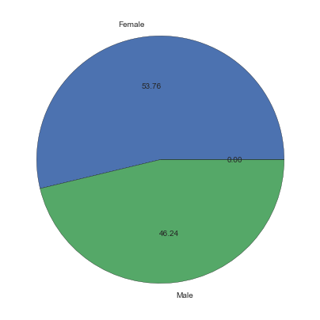

```python
#GENDER COMPOSITION - Pie chart showing the gender breakdown of the dataset
(df.gender.value_counts()/df.gender.count()*100).round(2).plot(kind='pie', autopct='%.2f', figsize=(7, 7))
```

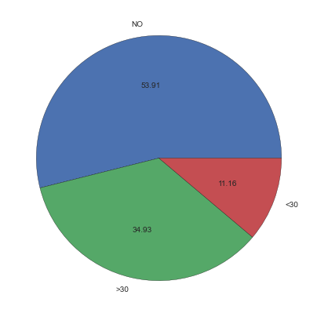

```python
#READMITTANCE TYPE - Pie chart showing the readmittance counts for the dataset
(df.readmitted.value_counts()/df.readmitted.count()*100).round(2).plot(kind='pie', autopct='%.2f', figsize=(7, 7))
```

**Interpretation**: This pie chart shows the readmittance attribute of the data set and its composition. It indicates that the most common 'type' of readmission is not being readmitted at all. If a patient IS readmitted, however, it is more likely they will be readmitted after at least 30 days. This attribute will be very important in the future.  
A pie chart was used because the chart attributes are each a portion of a whole. This is a great way to visualize exactly what portion of patients were readmitted, and if so, at what point after their previous visit.

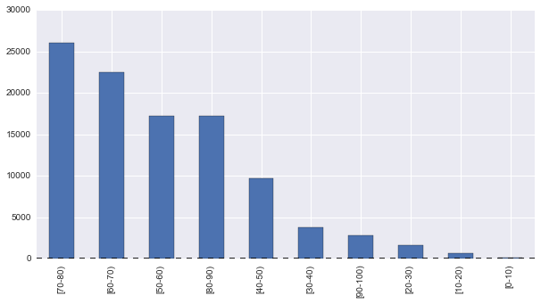

```python
#AGE BREAKDOWN - Bar chart showing the number of patients belonging to age categories
age = df.age.value_counts()
age.plot(kind='bar', figsize=(10, 5))
```

**Interpretation**: This bar chart shows the age distribution of the data set. It is rather surprising that so many of the patients included in this data set are of this age, however, it will be valuable in future analyses.  
A bar chart was used because a pie chart would have appeared to cluttered to understand. This chart is easy to comprehend and can help quickly communicate which age groups make up the majority of the data.

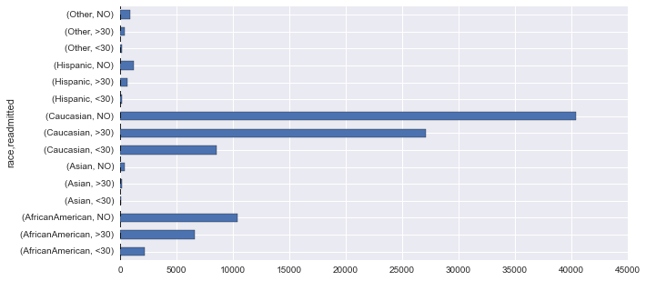

```python
#READMITTANCE BY RACE - Bar chart showing the number of times patients were readmitted, broken down by race
race_readmittance.plot(kind='barh', figsize=(10, 5))
```

**Interpretation**: This chart is not as meaningful as it could be, however, it does snow that the majority of patients, regardless of race, are no readmitted at all. In addition, if patients are readmitted, it is more likely that they will be readmitted at least 30 after the initial hospitalization than at any point during the proceeding month.  
Once I gain a better understanding of how to manipulate the data, I will try to convert these numbers into percentages. Each bar will represent the percent of the race as opposed to the count of overall readmittances.

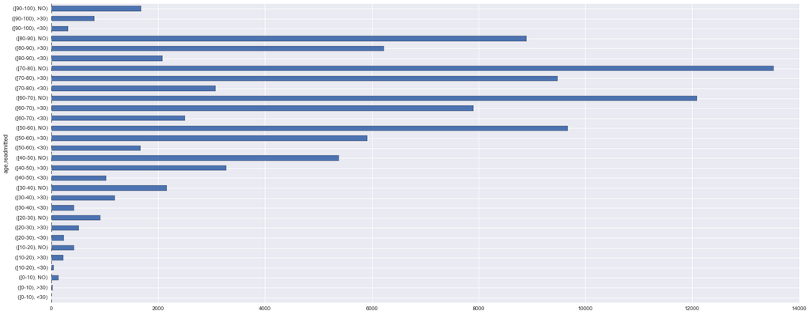

```python
#READMITTANCE BY AGE - Bar chart showing the number of times patients were readmitted, broken down by age
age_readmittance.plot(kind='barh', figsize=(25, 10))
```

**Interpretation**: This chart breaks down the type of readmittance by age. This data indicates that the regardless of age, patients are still readmitted at the same intervals. Not being readmitted is most likely, being readmitted more than 30 days after hospitalization is second likely and finally, it is least likely a patient will be readmitted in the proceeding month.  
Again, once I gain a better understanding of how to manipulate the data, I will try to convert these numbers into percentages. Each bar will represent the percent of the race as opposed to the count of overall readmittances.

```python
dfcopy = df
dfcopy.time_in_hospital = pd.cut(df.time_in_hospital,[0,1,2,3,4,5,6,7,1e4],8,labels=['0-1','1-2','2-3','3-4','4-5','5-6','6-7','7+']) # this creates a new variable
time_in_hospital = dfcopy.time_in_hospital.value_counts()

#print 'TIME IN HOSPITAL COMPOSITION'
#print time_in_hospital
#time_in_hospital.plot(kind='bar', figsize=(10, 5))
```

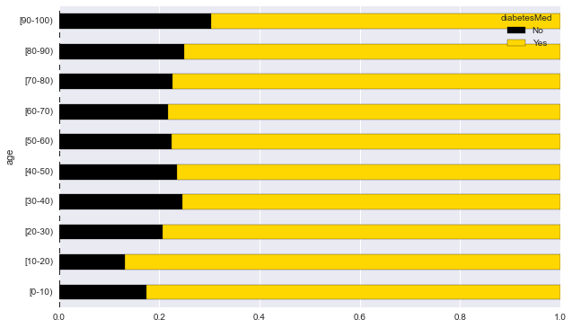

```python
#CROSS TABULATION BETWEEN AGE AND WHETHER DIABETES MEDICATION WAS ADMINISTERED
meds = pd.crosstab([df['age']], df.diabetesMed.astype(object))
meds_by_age = meds.div(meds.sum(1).astype(float),axis=0) # normalize the value
meds_by_age.plot(kind='barh', stacked=True, color=['black','gold'], figsize=(10, 6))
```

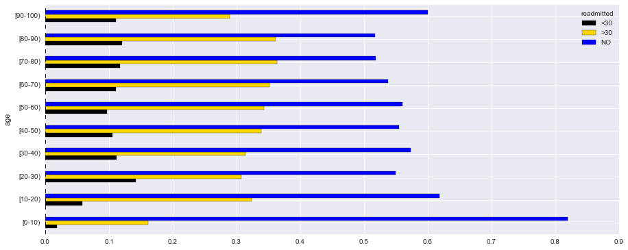

```python
#CROSS TABULATION BETWEEN READMISSION AND AGE
crosstab = pd.crosstab([df['age']], df.readmitted.astype(object))
readmission_by_age = crosstab.div(crosstab.sum(1).astype(float),axis=0) # normalize the value
readmission_by_age.plot(kind='barh', stacked=False, color=['black','gold','blue'], figsize=(15, 6))
```

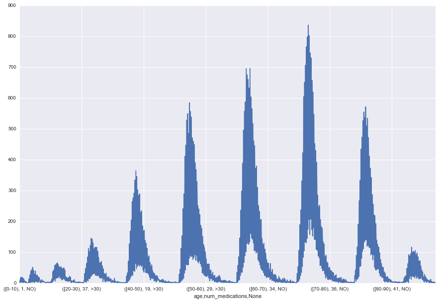

```python
#IMPACT OF AGE AND NUMBER OF MEDICATIONS UPON READMISSION
df_grouped2 = df.groupby(by=['age', 'num_medications'])
df_grouped2['readmitted'].value_counts().plot(kind='line',figsize=(15,10))
```

**Interpretation**: I'm not entirely sure what the chart represents, but I believe it shows the impact of the combination of age and the number of medications taken upon the likelyhood of being readmitted.

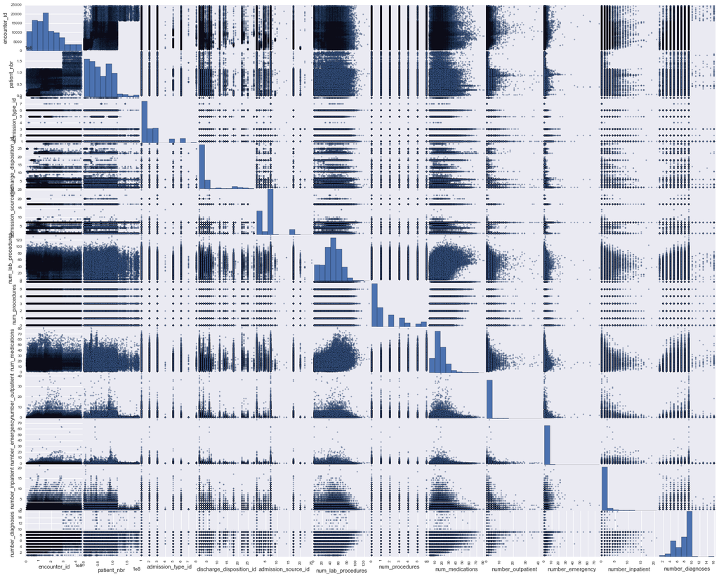

```python
from pandas.tools.plotting import scatter_matrix

#SCATTER MATRIX - This is useless at this point, but it was still interesting to try to use pandas functionality
#and creating a meaningful scatter matrix in the future will be an important analysis feature.
scatter = scatter_matrix(df,figsize=(25, 20))
```

**Interpretation**: This is a scatter matrix showing how attributes are correlated. The diagonal squares show the individual attribute graphed against values to display the distribution. The other squares indicate correlation by showing similar data. Some square show shapes that indiciate that clustering may be possible between these attributes.

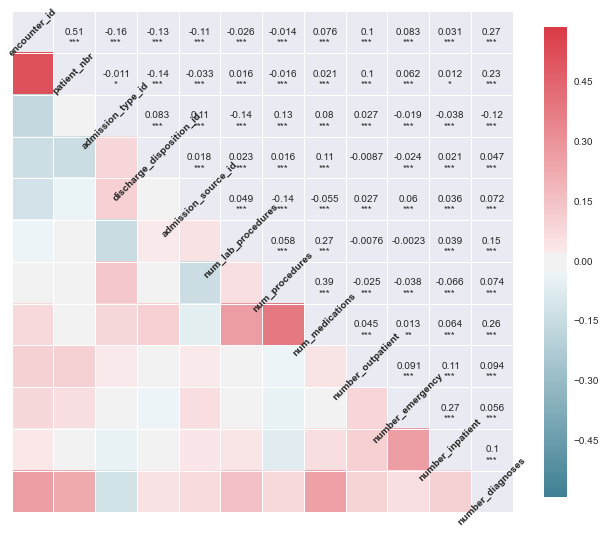

```python
cmap = sns.diverging_palette(220, 10, as_cmap=True) # one of the many color mappings


# plot the correlation matrix using seaborn
sns.set(style="darkgrid") # one of the many styles to plot using

f, ax = plt.subplots(figsize=(9, 9))

sns.corrplot(df,
             annot=True, # plot numeric annotations?
             sig_stars=True, # plot significance?
             diag_names=True,
             cmap=cmap,
             ax=ax)
f.tight_layout()
```

**Interpretation**: This is very similar to the scatter matrix above, however, instead of showing correlation with groupings and dark colors, this chart uses a color scale. The darker and redder the color, the greater the correlation between the attributes.

### Findings & Analysis

At this point, I have not found any features that have any significant correlation to patient readmission. There are quite a few interesting findings addressed above, some of which have already broken hypotheses about data such as the impact of gender upon the severity of admission. In the future, I plan on performing more detailed analyses of the impact of attributes such as gender, race, and previous admissions on overall readmissions.  
There are definitely some features that, if added to the data set, might yield some very interesting results. In particular, having details about patient weight would be very beneficial. It is dissapointing that the weight data is missing from this set because of the strong relationship between obesity and diabetes. In addition, having more detailed information about readmission would have been very beneficial. If a patient is readmitted a week later or 3 weeks later may have a huge impact ont the ability to predict readmission. Similarly, a patient may be readmitted 31 days after initial admission and or the may be readmitted 20 years later and the result on this model is still the same. If readmission was broken up into categories, it may yield more accurate predictions of the readmission attribute.  
Overall, this analysis was incredibly difficult. I struggled with how to convert data to a form which was more easily accessible. Most of the analyses done in class were done upon data sets with attributes that were primarily composed of int and float values. In addition, these attributes were easy to understand. This data set was primarily objects (albeit many of them were yes/no, however, they were primarily really detailed medical terms), which made some analyses difficult. I spent a large quantity of time referncing class notes and videos and trying to perform simlar steps on this data set, however, I was not successful a large portion of the time. In retrospect, I should have chosen an different data set for this project but at the time I was not aware of the difficulty associated with the attributes of this data set.  
Lastly, I tried to go above and beyond by making comments to the code and analysis whereever I could and by utilizing html/css to make this document as readable and organized as possible. It may not be worth much, but I think it was a fun way of tying my skillsets into this project.

### Personal Notes & References

- [Additional information on iPython support of HTML](https://github.com/github/markup/tree/master#html-sanitization)